# Dementia Prediction Analysis - Project

Ido Hasson & Netanel Abu

6/28/2020

# Preview

> What is Dementia?

According to WHO Dementia is a syndrome in which there is deterioration in memory, thinking, behaviour and the ability to perform everyday activities. Although dementia mainly affects older people, it is not a normal part of aging. Alzheimer disease is the most common form of dementia and may contribute to 60–70% of cases.

> In our project

In our project we try to predict and diagnose Dementia rating using some ML algorithms.

This dataset contain 150 subjects who scanned on two or more visits, separated by at least one year for a total of 373 imaging sessions, and we target the CDR fucntion

CDR is Clinical Dementia Rating (0 = no dementia, 0.5 = very mild AD, 1 = mild and moderate)

# Exploratory Data Analysis

## Loading Data

> Adding libraries

```r
library(ggplot2)
library(dplyr)
library(class)
library(caret)
library(gmodels)
library(corrplot)
library(klaR)
library(devtools)
library(ggbiplot)
library(Rtsne)
library(C50)
library(e1071)
library(randomForest)
library(kernlab)
library(factoextra)
library(C50)
library(purrr)
```

## Data Investigation

> Data’s head

```r
print(sample_n(mydata, 5))
```

```
##   Subject.ID        MRI.ID       Group Visit MR.Delay M.F Hand Age EDUC SES
## 1  OAS2_0076 OAS2_0076_MR3 Nondemented     3     1663   F    R  71   18   2
## 2  OAS2_0058 OAS2_0058_MR3    Demented     3      764   M    R  80   14   3
## 3  OAS2_0081 OAS2_0081_MR1    Demented     1        0   F    R  82   12   4
## 4  OAS2_0139 OAS2_0139_MR1    Demented     1        0   F    R  67   16   1
## 5  OAS2_0057 OAS2_0057_MR1 Nondemented     1        0   F    R  81   12   2
##   MMSE CDR eTIV  nWBV   ASF
## 1   30 0.0 1520 0.718 1.155
## 2   29 0.5 1324 0.695 1.326
## 3   26 0.5 1271 0.695 1.381
## 4   29 0.5 1337 0.766 1.312
## 5   30 0.0 1599 0.755 1.098
```

> Checking the structure of the data

```r
str(mydata)
```

```
## 'data.frame':    373 obs. of  15 variables:
##  $ Subject.ID: chr  "OAS2_0001" "OAS2_0001" "OAS2_0002" "OAS2_0002" ...
##  $ MRI.ID    : chr  "OAS2_0001_MR1" "OAS2_0001_MR2" "OAS2_0002_MR1" "OAS2_0002_MR2" ...
##  $ Group     : chr  "Nondemented" "Nondemented" "Demented" "Demented" ...
##  $ Visit     : int  1 2 1 2 3 1 2 1 2 3 ...
##  $ MR.Delay  : int  0 457 0 560 1895 0 538 0 1010 1603 ...
##  $ M.F       : chr  "M" "M" "M" "M" ...
##  $ Hand      : chr  "R" "R" "R" "R" ...
##  $ Age       : int  87 88 75 76 80 88 90 80 83 85 ...
##  $ EDUC      : int  14 14 12 12 12 18 18 12 12 12 ...
##  $ SES       : int  2 2 NA NA NA 3 3 4 4 4 ...
##  $ MMSE      : int  27 30 23 28 22 28 27 28 29 30 ...
##  $ CDR       : num  0 0 0.5 0.5 0.5 0 0 0 0.5 0 ...
##  $ eTIV      : int  1987 2004 1678 1738 1698 1215 1200 1689 1701 1699 ...
##  $ nWBV      : num  0.696 0.681 0.736 0.713 0.701 0.71 0.718 0.712 0.711 0.705 ...
##  $ ASF       : num  0.883 0.876 1.046 1.01 1.034 ...
```

## Explaining the variables

**Subject.ID** - Patient ID

**MRI.ID** - MRI Examination ID

**Group** (Converted / Demented / Nondemented) - Converted is a person that his diagnosed was changed after the first visit.

**Visit** - Number of visit

**MR.Delay** - Delay in days between each MRI examination (contrast)

#### Demographics Info

**M.F** - Gender (M if Male, F if Female)

**Hand** - Handedness(R/L)

**Age** - Age in years

**EDUC** - Years of education

**SES** - Socioeconomic status. 1 is highest status - 5 is the lowest status

#### Clinical Info

**MMSE** - Mini-Mental State Examination score (range is from 0 = worst to 30 = best)

**CDR** - Clinical Dementia Rating (0 = no dementia, 0.5 = very mild AD, 1 = mild AD, 2 = moderate AD)

#### Derived anatomic volumes

**eTIV** - Estimated total intracranial volume, mm3

**nWBV** - Normalized whole-brain volume, expressed as a percent of all voxels in the atlas-masked image that are labeled as gray or white matter by the automated tissue segmentation process

**ASF** - Atlas scaling factor (unitless). Computed scaling factor that transforms native-space brain and skull to the atlas target (i.e., the determinant of the transform matrix)

## Data cleanup

Replace missing values with the median

```r
sort(apply(mydata, 2, function(x){sum(is.na(x))}), decreasing = TRUE)
```

```
##        SES       MMSE Subject.ID     MRI.ID      Group      Visit   MR.Delay
##         19          2          0          0          0          0          0
##        M.F       Hand        Age       EDUC        CDR       eTIV       nWBV
##          0          0          0          0          0          0          0
##        ASF
##          0
```

```r
mydata$SES <- ifelse(is.na(mydata$SES), median(mydata$SES, na.rm = TRUE), mydata$SES)
mydata$MMSE <- ifelse(is.na(mydata$MMSE), median(mydata$MMSE, na.rm = TRUE), mydata$MMSE)
```

Concatenate low count of variable

```r
table(mydata$CD)
```

```
##
##   0 0.5   1   2
## 206 123  41   3
```

```r
mydata$CDR<-ifelse(mydata$CDR==2, 1, mydata$CDR)
```

In the ‘nondemented’ group there are 2 observations their CDR value is 0.5

```r
mydata[which(mydata$Group == "Nondemented" & mydata$CDR == .5),]
```

```
##    Subject.ID        MRI.ID       Group Visit MR.Delay M.F Hand Age EDUC SES
## 9   OAS2_0005 OAS2_0005_MR2 Nondemented     2     1010   M    R  83   12   4
## 31  OAS2_0017 OAS2_0017_MR3 Nondemented     3      617   M    R  81   12   3
##    MMSE CDR eTIV  nWBV   ASF
## 9    29 0.5 1701 0.711 1.032
## 31   27 0.5 1814 0.759 0.968
```

```r
mydata<-mydata[-c(9, 31),]
```

## Feature Selection

### Checking correlation

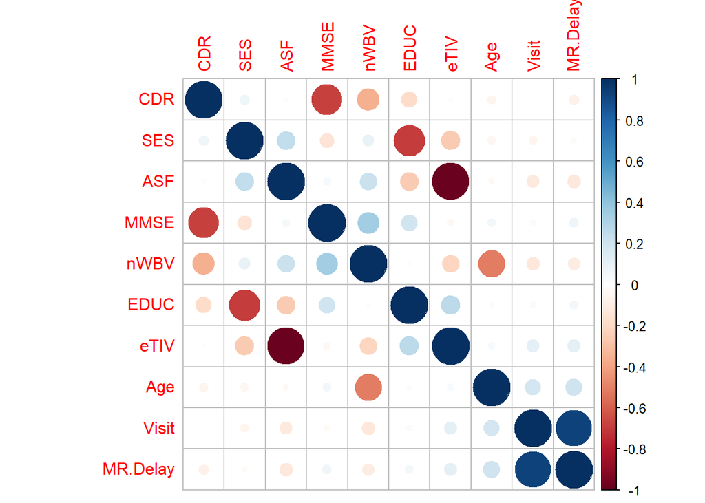

```r
mydata$Group<-as.factor(mydata$Group)
mydata$M.F<-as.factor(mydata$M.F)
numeric_variables <- mydata[, sapply(mydata, is.numeric)]

correlations <- cor(numeric_variables)
corrplot(correlations, order = "hclust")
```

### RFE

> Recursive Feature Selection

```r
# ensure the results are repeatable
set.seed(7)
# load the library
# define the control using a random forest selection function
control <- rfeControl(functions=rfFuncs, method="cv", number=10)
mydata=mydata[c(1,2,3,4,5,6,7,8,9,10,11,13,14,15,12)]
# run the RFE algorithm
results <- rfe(mydata[,6:14], mydata[,15], sizes=c(1:14), rfeControl=control)
# summarize the results
print(results)
```

```
##
## Recursive feature selection
##
## Outer resampling method: Cross-Validated (10 fold)
##
## Resampling performance over subset size:
##
##  Variables   RMSE Rsquared    MAE  RMSESD RsquaredSD   MAESD Selected
##          1 0.2451   0.5063 0.1857 0.02687    0.10973 0.02268
##          2 0.2533   0.4818 0.1962 0.02985    0.11603 0.02519
##          3 0.2497   0.4926 0.1947 0.02403    0.11000 0.01504
##          4 0.2406   0.5308 0.1864 0.02269    0.10350 0.01608
##          5 0.2300   0.5769 0.1816 0.02191    0.10985 0.01760
##          6 0.2267   0.5798 0.1717 0.02400    0.10525 0.01862
##          7 0.2213   0.6014 0.1691 0.02170    0.09641 0.01921
##          8 0.2185   0.6164 0.1683 0.02249    0.09806 0.02014        *
##          9 0.2188   0.6089 0.1669 0.02476    0.10489 0.02104
##
## The top 5 variables (out of 8):
##    MMSE, nWBV, EDUC, eTIV, Age
```

```r
# list the chosen features
predictors(results)
```

```
## [1] "MMSE" "nWBV" "EDUC" "eTIV" "Age"  "ASF"  "M.F"  "SES"
```

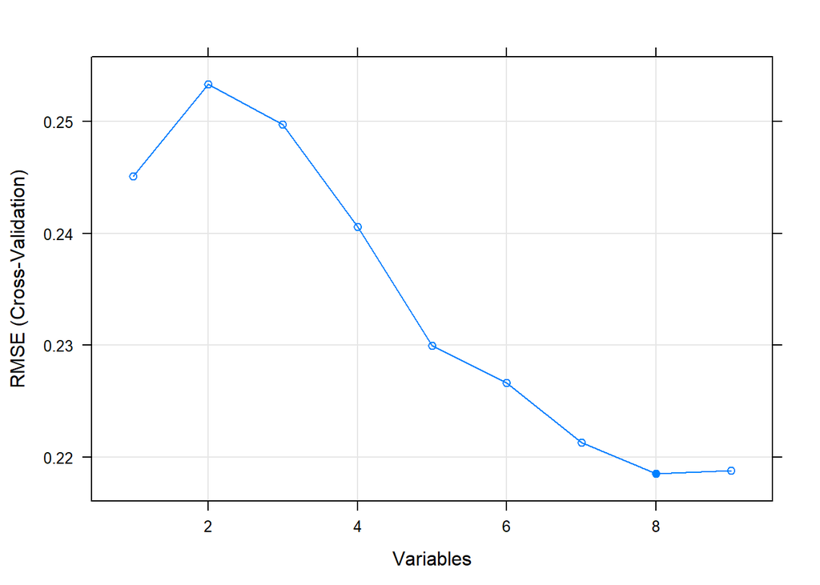

```r
# plot the results
plot(results, type=c("g", "o"))
```

> Finally select features

after consider the correlation and the output of RFE we made a decision and eliminate some features.

Dropping the ‘Hand’ column since all patients are right handed

```r
unique(mydata$Hand)
```

```
## [1] "R"
```

```r
mydata <- subset(mydata, select = -Hand)
```

```r
mydata %>%
    dplyr::select(Subject.ID, Age, CDR, M.F) %>%
    group_by(Subject.ID, CDR, M.F) %>%
    summarise_all(funs(min)) %>%
    as.data.frame() %>%
    mutate(CDR = as.factor(CDR))
```

```r
newdata <- mydata %>%
  dplyr::select(M.F, Age, EDUC, SES, MMSE, eTIV, nWBV, ASF, CDR) %>%
  mutate(CDR = as.factor(CDR))
```

Change the gender from chars to numeric

```r
newdata$M.F <- ifelse(mydata$M.F=="M", 1, 0)
```

## Visualization

> CDR VS MMSE (Mini-Mental State Examination score (range is from 0 = worst to 30 = best))

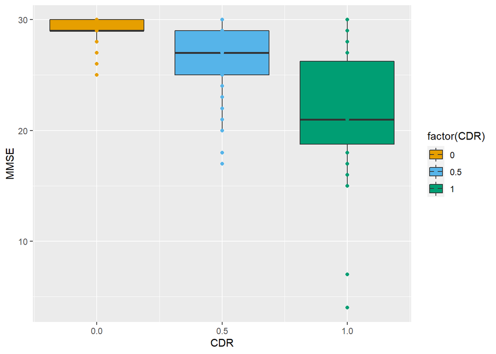

```r
# Plot
ggplot(data = mydata, aes(x = CDR, y = MMSE)) +
  geom_boxplot(aes(fill=factor(CDR))) +
  geom_point(aes(color = factor(CDR))) +
  scale_x_continuous(breaks = c(0, 0.5, 1,2,3)) +
  scale_colour_manual(breaks = c("0", "0.5", "1", "2", "3"),
                      values = c("#E69F00", "#56B4E9", "#009E73",
                                 "#F0E442", "#0072B2")) +
  scale_fill_manual(breaks = c("0", "0.5", "1", "2", "3"),
                      values = c("#E69F00", "#56B4E9", "#009E73",
                                 "#F0E442", "#0072B2"))
```

As we excpected, when the CDR Level is higher (Dementia is more severe) the MMSE test’s score decrease.

> CDR vs nwBV (Normalized whole-brain volume)

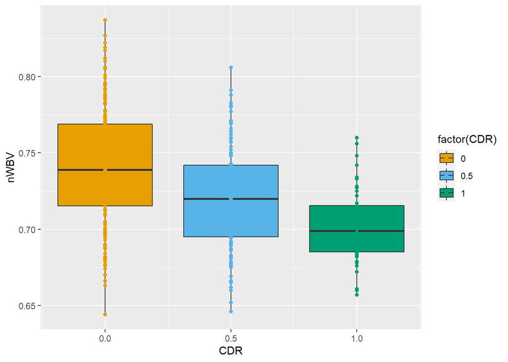

```r
# Plot
ggplot(data = mydata, aes(x = CDR, y = nWBV)) +
  geom_boxplot(aes(fill=factor(CDR))) +
  geom_point(aes(color = factor(CDR))) +
  scale_x_continuous(breaks = c(0, 0.5, 1,2,3)) +
  scale_colour_manual(breaks = c("0", "0.5", "1", "2", "3"),
                      values = c("#E69F00", "#56B4E9", "#009E73",
                                 "#F0E442", "#0072B2")) +
  scale_fill_manual(breaks = c("0", "0.5", "1", "2", "3"),
                      values = c("#E69F00", "#56B4E9", "#009E73",
                                 "#F0E442", "#0072B2"))
```

We can see that the whole-brain volume decrease when the CDR is higher

> CDR level by Age

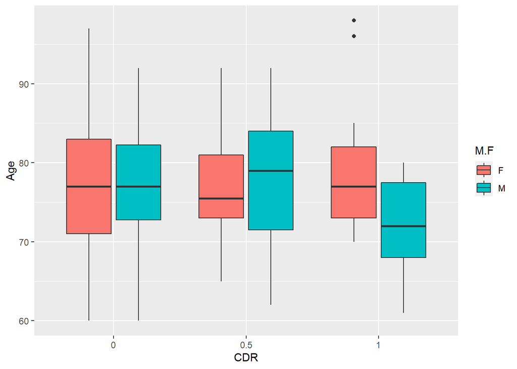

```r
ggplot(data = mydata, aes(as.factor(CDR), Age, fill = M.F))+
  geom_boxplot()+
  xlab("CDR")+
  theme(plot.title = element_text(hjust = .5))
```

there is no significant difference between the groups when the CDR is low. When CDR is higher we can see that males are more sensitive. (median of males ~72, females ~ 78)

## Features Reduction Algorithms

### PCA

> PCA

```r
newdata$CDR=as.numeric(newdata$CDR)
pca_result <- prcomp(newdata, center = TRUE, scale = TRUE)
summary(pca_result)
```

```
## Importance of components:
##                           PC1    PC2    PC3    PC4     PC5     PC6     PC7
## Standard deviation     1.6739 1.4639 1.1851 1.0948 0.72393 0.58089 0.56110
## Proportion of Variance 0.3113 0.2381 0.1560 0.1332 0.05823 0.03749 0.03498
## Cumulative Proportion  0.3113 0.5494 0.7055 0.8386 0.89687 0.93436 0.96935
##                            PC8     PC9
## Standard deviation     0.51482 0.10416
## Proportion of Variance 0.02945 0.00121
## Cumulative Proportion  0.99879 1.00000
```

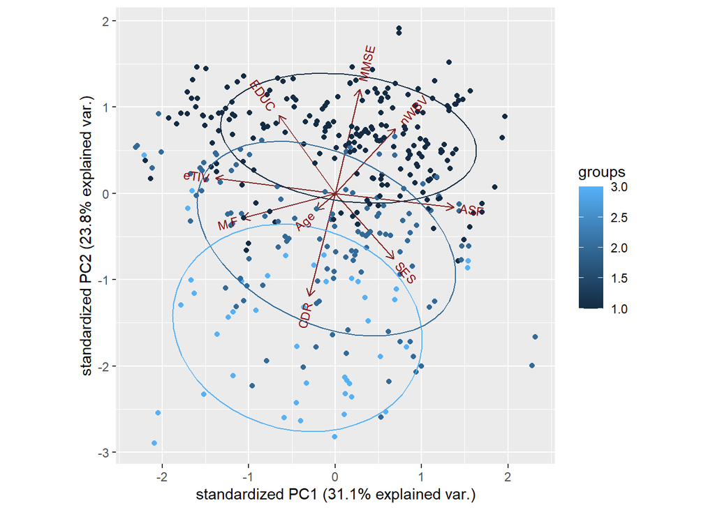

```r
ggbiplot(pca_result,ellipse=TRUE, groups=newdata$CDR)
```

### T-Sne

> T-Sne

```r
iris_unique <- unique(newdata) # Remove duplicates
iris_matrix <- as.matrix(iris_unique[,1:8])
set.seed(42)
tsne <- Rtsne(newdata[,-9], dims = 2, perplexity=30, verbose=TRUE, max_iter = 500)
```

```
## Performing PCA
## Read the 371 x 8 data matrix successfully!
## OpenMP is working. 1 threads.
## Using no_dims = 2, perplexity = 30.000000, and theta = 0.500000
## Computing input similarities...
## Building tree...
## Done in 0.07 seconds (sparsity = 0.287967)!
## Learning embedding...
## Iteration 50: error is 48.435563 (50 iterations in 0.05 seconds)
## Iteration 100: error is 45.635460 (50 iterations in 0.06 seconds)
## Iteration 150: error is 44.943050 (50 iterations in 0.06 seconds)
## Iteration 200: error is 44.722759 (50 iterations in 0.04 seconds)
## Iteration 250: error is 44.609955 (50 iterations in 0.05 seconds)
## Iteration 300: error is 0.229294 (50 iterations in 0.04 seconds)
## Iteration 350: error is 0.189805 (50 iterations in 0.04 seconds)
## Iteration 400: error is 0.177066 (50 iterations in 0.04 seconds)
## Iteration 450: error is 0.170998 (50 iterations in 0.04 seconds)
## Iteration 500: error is 0.169094 (50 iterations in 0.04 seconds)
## Fitting performed in 0.45 seconds.
```

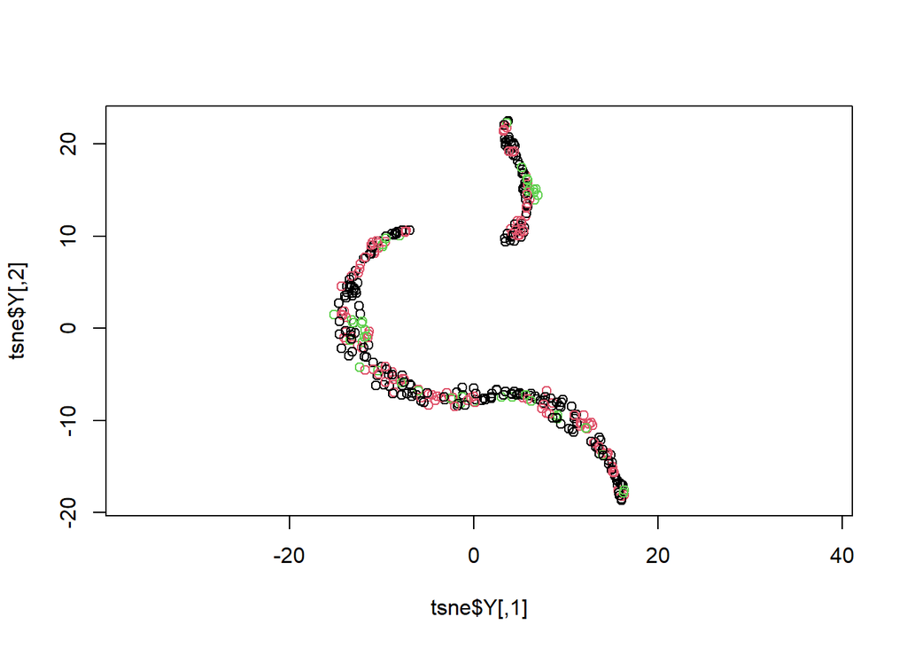

```r
plot(tsne$Y,col=iris_unique$CDR, asp=1)
```

# ML Classicifation Algorithms

> Normalize function

```r
normalize <- function(x) {
return ((x - min(x)) / (max(x) - min(x)))
}
```

> Normalized data dataframe

```r
n_data <- as.data.frame(lapply(newdata[1:8], normalize))
```

> Preparing data for KNN

> Change the target from factor to numeric

KNN doesn’t like factor therefore we changed the column to numeric now the new CDR is -

1 = no dementia, 2 = very mild AD, 3 = mild / moderate AD

instead of -

0 = no dementia, 0.5 = very mild AD, 1 = mild / moderate AD

```r
newdata$CDR<-as.numeric(newdata$CDR)
```

#### Divide data to train and test sets

```r
ind <- sample(2, nrow(n_data), replace=TRUE, prob=c(0.7,0.3))
train <- n_data[ind==1,]
test <- n_data[ind==2,]

train_labels <- newdata[ind==1, 9]
test_labels <- newdata[ind==2, 9]
```

## First algorithm - KNN

### K=1

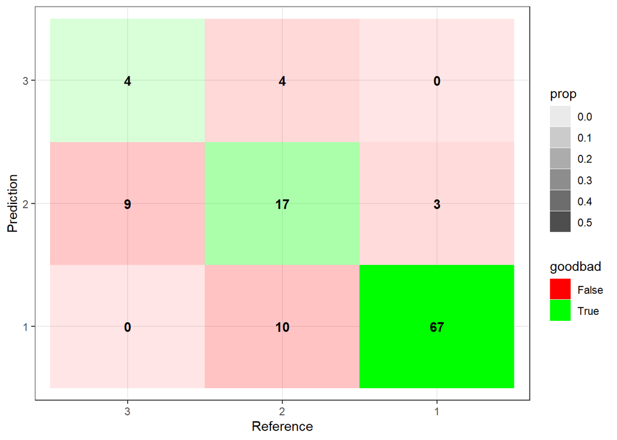

```r
test_pred <- knn(train = train, test = test, cl = train_labels, k=1)
pred_table <- confusionMatrix(reference = as.factor(test_labels), data = test_pred)
table <- data.frame(pred_table$table)

plotTable <- table %>%
  mutate(goodbad = ifelse(table$Prediction == table$Reference, "True", "False")) %>%
  group_by(Reference) %>%
  mutate(prop = Freq/sum(Freq))
ggplot(data = plotTable, mapping = aes(x = Reference, y = Prediction, fill = goodbad, alpha = prop)) +
  geom_tile() +
  geom_text(aes(label = Freq), vjust = .5, fontface  = "bold", alpha = 1)  +
  scale_fill_manual(values = c(True = "green", False = "red")) +
  theme_bw()+
  xlim(rev(levels(table$Reference)))
```

```r
print(paste("Accuracy in percent is:",pred_table$overall[1]*100))
```

```
## [1] "Accuracy in percent is: 77.1929824561403"
```

```r
print(paste("Kappa in percent is:",pred_table$overall[2]*100))
```

```
## [1] "Kappa in percent is: 55.1113130395275"
```

### K=3

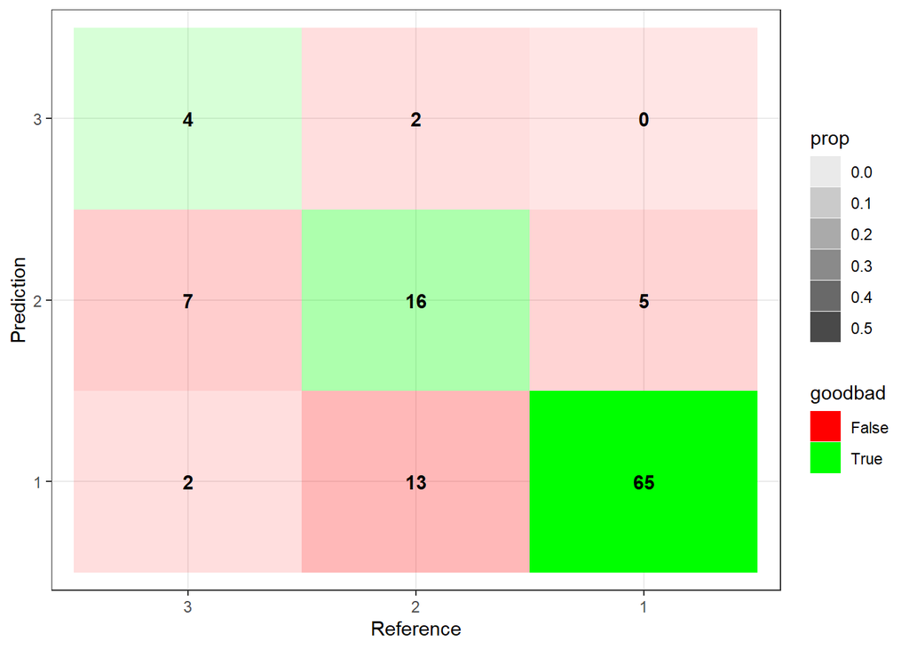

```r
test_pred3 <- knn(train = train, test = test, cl = train_labels, k=3)
pred_table3 <- confusionMatrix(reference = as.factor(test_labels), data = test_pred3)
table <- data.frame(pred_table3$table)

plotTable <- table %>%
  mutate(goodbad = ifelse(table$Prediction == table$Reference, "True", "False")) %>%
  group_by(Reference) %>%
  mutate(prop = Freq/sum(Freq))
ggplot(data = plotTable, mapping = aes(x = Reference, y = Prediction, fill = goodbad, alpha = prop)) +
  geom_tile() +
  geom_text(aes(label = Freq), vjust = .5, fontface  = "bold", alpha = 1)  +
  scale_fill_manual(values = c(True = "green", False = "red")) +
  theme_bw()+
  xlim(rev(levels(table$Reference)))
```

```r
print(paste("Accuracy in percent is:",pred_table3$overall[1]*100))
```

```
## [1] "Accuracy in percent is: 74.5614035087719"
```

```r
print(paste("Kappa in percent is:",pred_table3$overall[2]*100))
```

```
## [1] "Kappa in percent is: 48.7441860465116"
```

### K=5

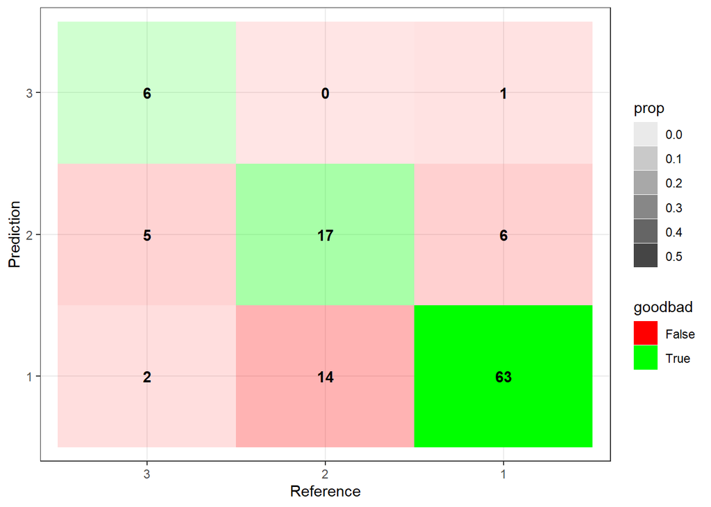

```r
test_pred5 <- knn(train = train, test = test, cl = train_labels, k=5)
pred_table5 <- confusionMatrix(reference = as.factor(test_labels), data = test_pred5)
table <- data.frame(pred_table5$table)

plotTable <- table %>%
  mutate(goodbad = ifelse(table$Prediction == table$Reference, "True", "False")) %>%
  group_by(Reference) %>%
  mutate(prop = Freq/sum(Freq))
ggplot(data = plotTable, mapping = aes(x = Reference, y = Prediction, fill = goodbad, alpha = prop)) +
  geom_tile() +
  geom_text(aes(label = Freq), vjust = .5, fontface  = "bold", alpha = 1)  +
  scale_fill_manual(values = c(True = "green", False = "red")) +
  theme_bw()+
  xlim(rev(levels(table$Reference)))
```

```r
print(paste("Accuracy in percent is:",pred_table5$overall[1]*100))
```

```
## [1] "Accuracy in percent is: 75.4385964912281"
```

```r
print(paste("Kappa in percent is:",pred_table5$overall[2]*100))
```

```
## [1] "Kappa in percent is: 50.9451360073767"
```

### K=9

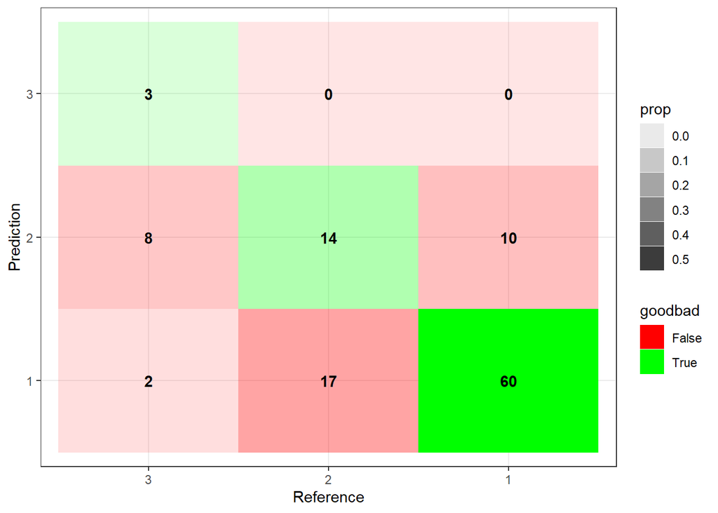

```r
test_pred9 <- knn(train = train, test = test, cl = train_labels, k=9)
pred_table9 <- confusionMatrix(reference = as.factor(test_labels), data = test_pred9)
table <- data.frame(pred_table9$table)

plotTable <- table %>%
  mutate(goodbad = ifelse(table$Prediction == table$Reference, "True", "False")) %>%
  group_by(Reference) %>%
  mutate(prop = Freq/sum(Freq))
ggplot(data = plotTable, mapping = aes(x = Reference, y = Prediction, fill = goodbad, alpha = prop)) +
  geom_tile() +
  geom_text(aes(label = Freq), vjust = .5, fontface  = "bold", alpha = 1)  +
  scale_fill_manual(values = c(True = "green", False = "red")) +
  theme_bw()+
  xlim(rev(levels(table$Reference)))
```

```r
print(paste("Accuracy in percent is:",pred_table9$overall[1]*100))
```

```
## [1] "Accuracy in percent is: 67.5438596491228"
```

```r
print(paste("Kappa in percent is:",pred_table9$overall[2]*100))
```

```
## [1] "Kappa in percent is: 34.4522144522144"
```

### K=17

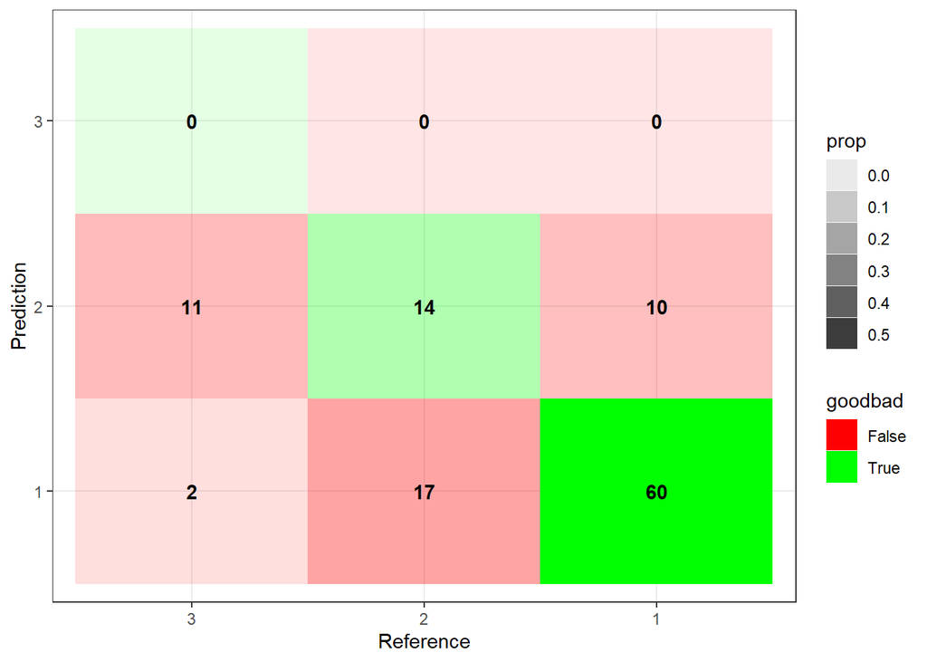

```r
test_pred17 <- knn(train = train, test = test, cl = train_labels, k=17)
pred_table17 <- confusionMatrix(reference = as.factor(test_labels), data = test_pred17)
table <- data.frame(pred_table17$table)

plotTable <- table %>%
  mutate(goodbad = ifelse(table$Prediction == table$Reference, "True", "False")) %>%
  group_by(Reference) %>%
  mutate(prop = Freq/sum(Freq))
ggplot(data = plotTable, mapping = aes(x = Reference, y = Prediction, fill = goodbad, alpha = prop)) +
  geom_tile() +
  geom_text(aes(label = Freq), vjust = .5, fontface  = "bold", alpha = 1)  +
  scale_fill_manual(values = c(True = "green", False = "red")) +
  theme_bw()+
  xlim(rev(levels(table$Reference)))
```

```r
print(paste("Accuracy in percent is:",pred_table17$overall[1]*100))
```

```
## [1] "Accuracy in percent is: 64.9122807017544"
```

```r
print(paste("Kappa in percent is:",pred_table17$overall[2]*100))
```

```
## [1] "Kappa in percent is: 28.5378467324871"
```

### K=29

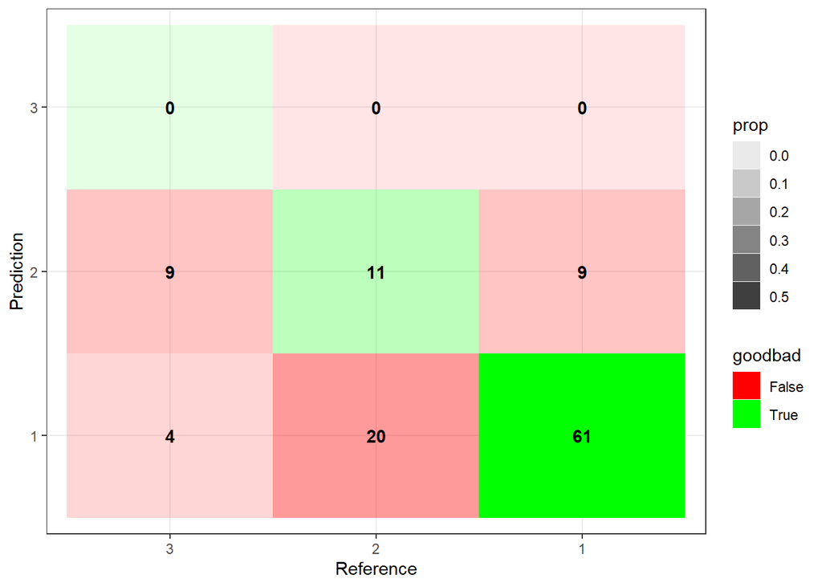

```r
test_pred29 <- knn(train = train, test = test, cl = train_labels, k=29)
pred_table29 <- confusionMatrix(reference = as.factor(test_labels), data = test_pred29)
table <- data.frame(pred_table29$table)
plotTable <- table %>%
  mutate(goodbad = ifelse(table$Prediction == table$Reference, "True", "False")) %>%
  group_by(Reference) %>%
  mutate(prop = Freq/sum(Freq))
ggplot(data = plotTable, mapping = aes(x = Reference, y = Prediction, fill = goodbad, alpha = prop)) +
  geom_tile() +
  geom_text(aes(label = Freq), vjust = .5, fontface  = "bold", alpha = 1)  +
  scale_fill_manual(values = c(True = "green", False = "red")) +
  theme_bw()+
  xlim(rev(levels(table$Reference)))
```

```r
print(paste("Accuracy in percent is:",pred_table29$overall[1]*100))
```

```
## [1] "Accuracy in percent is: 63.1578947368421"
```

```r
print(paste("Kappa in percent is:",pred_table29$overall[2]*100))
```

```
## [1] "Kappa in percent is: 22.108345534407"
```

## Second algorithm - Naive Bayes

> Changing the CDR back to factor for the Naive Bayes

```r
newdata$CDR=as.factor(newdata$CDR)
```

> Divide to train and test sets

```r
ind <- sample(2, nrow(newdata), replace=TRUE, prob=c(0.7,0.3))
nbtrain <- newdata[ind==1,]
nbtest <- newdata[ind==2,]
```

> Predict

```r
nb_mod <- NaiveBayes(CDR ~ ., data = nbtrain)
pred <- predict(nb_mod, nbtest)
```

> Confusion Matrix

```r
tab <- table(pred$class, nbtest$CDR)
caret::confusionMatrix(tab)
```

```
## Confusion Matrix and Statistics
##
##
##      1  2  3
##   1 50 11  2
##   2  6 19  5
##   3  0  3  9
##
## Overall Statistics
##
##                Accuracy : 0.7429
##                  95% CI : (0.6483, 0.8232)
##     No Information Rate : 0.5333
##     P-Value [Acc > NIR] : 8.305e-06
##
##                   Kappa : 0.5511
##
##  Mcnemar's Test P-Value : 0.2647
##
## Statistics by Class:
##
##                      Class: 1 Class: 2 Class: 3
## Sensitivity            0.8929   0.5758  0.56250
## Specificity            0.7347   0.8472  0.96629
## Pos Pred Value         0.7937   0.6333  0.75000
## Neg Pred Value         0.8571   0.8133  0.92473
## Prevalence             0.5333   0.3143  0.15238
## Detection Rate         0.4762   0.1810  0.08571
## Detection Prevalence   0.6000   0.2857  0.11429
## Balanced Accuracy      0.8138   0.7115  0.76440
```

> Plot the Confusion Matrix

[figure not shown]

```r
nbtest$pred <- pred$class
ggplot(nbtest, aes(CDR, pred, color = CDR)) +
  geom_jitter(width = 0.2, height = 0.1, size=2) +
  labs(title="Confusion Matrix",
       subtitle="Predicted vs. Observed from Iris dataset",
       y="Predicted",
       x="Truth",
       caption="machinelearningplus.com")
```

## Third Algorithm - Descision Tree

> Divide to train and test sets

```r
ind <- sample(2, nrow(newdata), replace=TRUE, prob=c(0.7,0.3))
dttrain <- newdata[ind==1,]
dttest <- newdata[ind==2,]
```

> Training a model

```r
dt_model <- C5.0(newdata[-9], as.factor(newdata$CDR))
```

```r
dt_pred <- predict(dt_model, dttest)

CrossTable(dttest$CDR, dt_pred, prop.chisq = FALSE, prop.c = FALSE, prop.r = FALSE, dnn = c('actual default', 'predicted default'))
```

```
##
##
##    Cell Contents
## |-------------------------|
## |                       N |
## |         N / Table Total |
## |-------------------------|
##
##
## Total Observations in Table:  127
##
##
##                | predicted default
## actual default |         1 |         2 |         3 | Row Total |
## ---------------|-----------|-----------|-----------|-----------|
##              1 |        66 |         3 |         0 |        69 |
##                |     0.520 |     0.024 |     0.000 |           |
## ---------------|-----------|-----------|-----------|-----------|
##              2 |         6 |        38 |         1 |        45 |
##                |     0.047 |     0.299 |     0.008 |           |
## ---------------|-----------|-----------|-----------|-----------|
##              3 |         1 |         4 |         8 |        13 |
##                |     0.008 |     0.031 |     0.063 |           |
## ---------------|-----------|-----------|-----------|-----------|
##   Column Total |        73 |        45 |         9 |       127 |
## ---------------|-----------|-----------|-----------|-----------|
##
##
```

> Visulaization of the tree

[figure not shown]

```r
plot(dt_model)
```

## Fourth Algorithm - Random Forrest

```r
set.seed(171)
rfmodel <- randomForest(CDR ~ ., data=newdata, importance=TRUE,
                        proximity=TRUE)
print(rfmodel)
```

```
##
## Call:
##  randomForest(formula = CDR ~ ., data = newdata, importance = TRUE,      proximity = TRUE)
##                Type of random forest: classification
##                      Number of trees: 500
## No. of variables tried at each split: 2
##
##         OOB estimate of  error rate: 21.83%
## Confusion matrix:
##     1  2  3 class.error
## 1 188 18  0  0.08737864
## 2  36 78  7  0.35537190
## 3   4 16 24  0.45454545
```

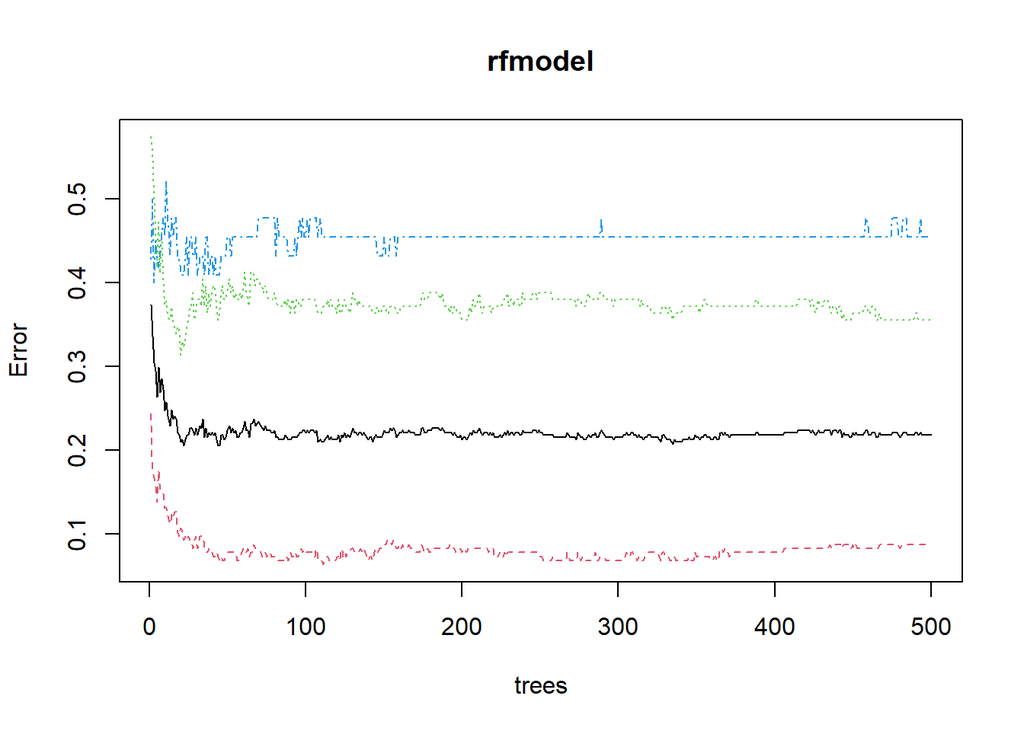

```r
plot(rfmodel)
```

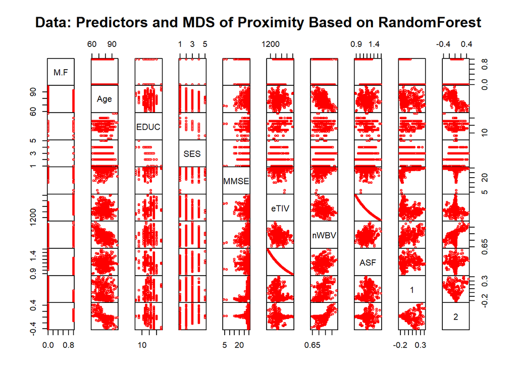

```r
rf.mds <- cmdscale(1 - rfmodel$proximity, eig=TRUE)
op <- par(pty="s")
pairs(cbind(newdata[,1:8], rf.mds$points), cex=0.6, gap=0,
      col=c("red", "green", "blue")[as.numeric(mydata$CDR)],
      main="Data: Predictors and MDS of Proximity Based on RandomForest")
```

```r
par(op)
print(rf.mds$GOF)
```

```
## [1] 0.08970381 0.10029620
```

Let’s check which features are the most important in the RF model

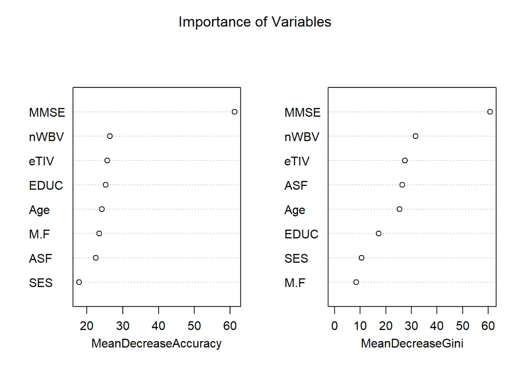

```r
varImpPlot(rfmodel, main = "Importance of Variables")
```

## Fifth Algorithm - SVM

```r
ind <- sample(2, nrow(newdata), replace=TRUE, prob=c(0.7,0.3))
svmtrain <- newdata[ind==1,]
svmtest <- newdata[ind==2,]
svm_classifier <- ksvm(CDR ~ ., data = svmtrain, kernel = "vanilladot")
svm_pred <- predict(svm_classifier, svmtest)
agreement <- svm_pred == svmtest$CDR
table(agreement)
```

```
## agreement
## FALSE  TRUE
##    29    82
```

```r
svm_classifier2 <- ksvm(CDR ~ ., data = svmtrain, kernel = "rbfdot")
svm_pred2 <- predict(svm_classifier2, svmtest)
agreement <- svm_pred2 == svmtest$CDR
table(agreement)
```

```
## agreement
## FALSE  TRUE
##    34    77
```

We’ve tried 2 SVM models with different kernels, and we can see that vanilladot better gave us better results.

# ML Clustering Algorithm

## K-Means

> Elbow Method

K-Means is an algorithm for unsupervised data, elbow method help to determine how many clusters there are in the data

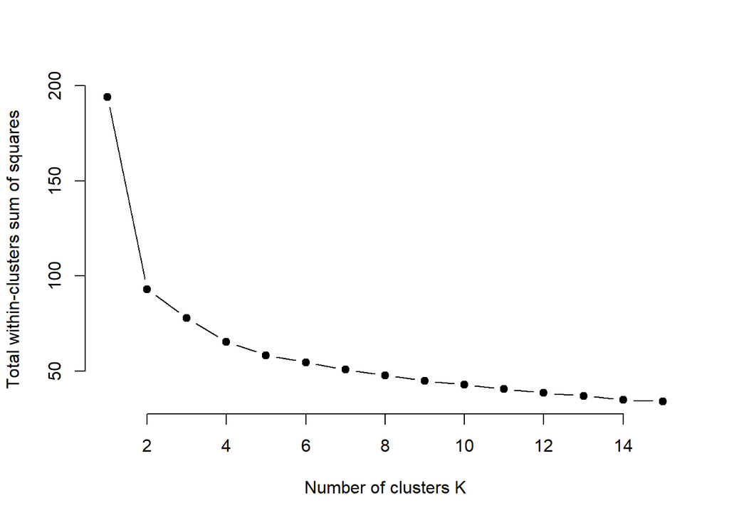

```r
set.seed(123)

# function to compute total within-cluster sum of square
wss <- function(k) {
  kmeans(n_data, k, nstart = 10 )$tot.withinss
}

# Compute and plot wss for k = 1 to k = 15
k.values <- 1:15

# extract wss for 2-15 clusters
wss_values <- map_dbl(k.values, wss)

plot(k.values, wss_values,
       type="b", pch = 19, frame = FALSE,
       xlab="Number of clusters K",
       ylab="Total within-clusters sum of squares")
```

> K-Means, K=3

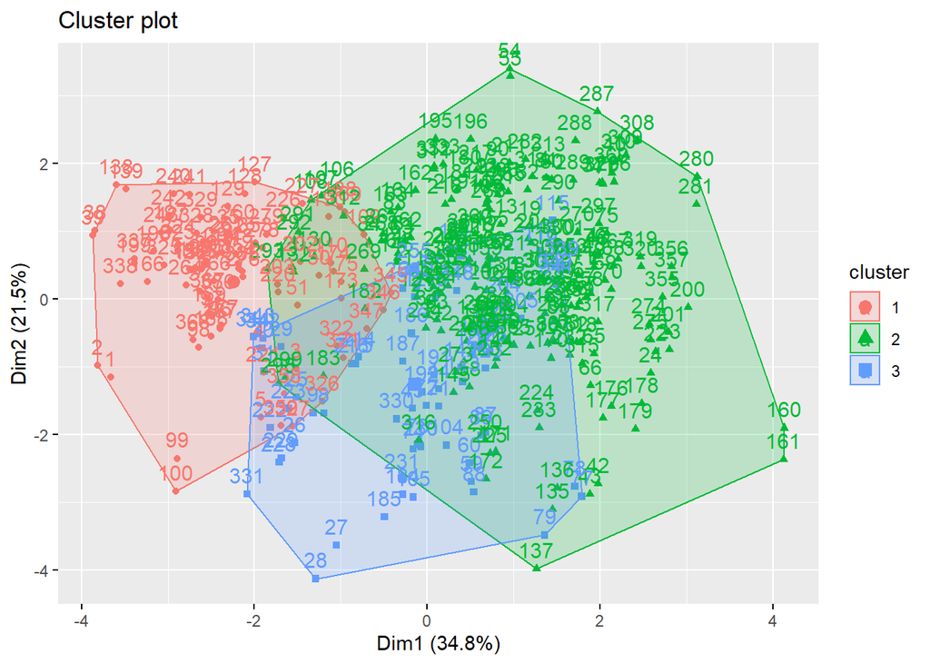

```r
set.seed(2000)
kmeansmodel<- kmeans(n_data, centers = 3, nstart = 25)
fviz_cluster(kmeansmodel, data = n_data)
```

```r
kmeansmodel
```

```
## K-means clustering with 3 clusters of sizes 88, 213, 70
##
## Cluster means:
##   M.F       Age      EDUC       SES      MMSE      eTIV      nWBV       ASF
## 1   1 0.4425837 0.6350267 0.1193182 0.8868007 0.6446649 0.3669336 0.2418968
## 2   0 0.4542871 0.4926816 0.3708920 0.9187432 0.3283300 0.4849303 0.5437293
## 3   1 0.4304511 0.3873950 0.6178571 0.8489011 0.4372574 0.4121392 0.4306209
##
## Clustering vector:
##   [1] 1 1 1 1 1 2 2 3 3 3 3 3 2 2 3 3 2 2 2 2 2 2 2 2 3 3 3 3 3 3 3 2 2 2 1 1 1
##  [38] 1 1 2 2 2 2 3 3 2 2 2 2 1 1 2 2 2 2 2 2 2 3 3 2 2 2 2 2 2 2 2 2 2 3 3 3 3
##  [75] 2 2 3 3 3 2 2 2 2 2 2 2 3 3 3 2 2 2 2 2 2 1 1 1 1 1 2 2 2 3 3 2 2 2 1 1 2
## [112] 2 2 2 3 3 2 2 2 2 2 3 3 3 3 3 1 1 1 2 2 2 2 2 2 2 2 1 1 3 3 3 3 2 2 2 2 1
## [149] 1 1 1 1 2 2 2 2 2 2 2 2 2 2 2 2 1 1 1 1 1 2 2 2 1 1 1 2 2 2 2 2 2 2 2 3 3
## [186] 3 3 1 1 1 3 3 2 2 2 2 1 1 1 2 2 1 1 3 3 2 2 2 2 2 2 2 2 3 3 3 2 2 2 1 1 3
## [223] 3 2 2 1 1 3 3 3 3 2 2 2 2 2 2 2 2 1 1 1 1 2 2 2 2 2 2 2 2 2 2 2 3 3 2 2 2
## [260] 1 1 1 1 1 2 2 2 2 2 2 2 2 2 2 2 1 1 1 1 2 2 2 2 2 2 2 2 2 2 2 2 2 2 1 1 2
## [297] 2 2 2 2 2 2 2 2 2 2 2 2 2 2 2 2 2 2 2 2 2 2 2 2 1 1 1 1 1 1 1 1 1 3 3 2 2
## [334] 1 1 1 1 1 3 3 3 3 3 3 1 1 1 3 3 2 2 2 1 1 2 2 2 1 1 2 2 2 2 2 2 1 1 1 2 2
## [371] 2
##
## Within cluster sum of squares by cluster:
## [1] 13.50475 49.39674 14.83971
##  (between_SS / total_SS =  59.9 %)
##
## Available components:
##
## [1] "cluster"      "centers"      "totss"        "withinss"     "tot.withinss"
## [6] "betweenss"    "size"         "iter"         "ifault"
```

# Summary

First let’s remember that Dementia is not easy too predict, especially in very mild levels, it’s a mental issue that not physically visible and has a large scale of levels, makes it hard to determine by doctors and by machine learning.

other models like svm and rf gave us good results too. the KNN model has around 80% accuracy in k=1 and less in greater k values, maybe our features are too close to each other, without huge difference, and when the KNN try to group bigger groups by Euclidean distance, we get many False results.

With Naïve Bayes, we assume that the predictor variables are conditionally independent of one another. maybe in our data is an advantage because most of our features are weakly correlated to the target, therefore the results was the good and pretty similiar for k=1 in KNN.

The results highly depends on the MMSE test while Age, Educational Level and Social-Economic Status have not great influence.